# Using FREEC to analyse CNVs in wild maize

Simon Renny-Byfield

February 3, 2015

As part of my project we are interested in calling PAV-CNV in 20 teosinte individuals from a single population near Palmar Chico, Mexico. I have tried a number of options, none of which are producing what seems like sensible results and so I have decided to pursue different approaches.

FREEC infers “control-free copy number alteration (CNA)” detection using deep-sequencing data. The installation is standard and won’t be detailed here but there are quite a few auxiliary files that are needed and I will go through how these are generated.

## The config file

FREEC requires the generation of a config file. An example of such a file is given below:

```
[general]

chrLenFile = hs18_chr.len
coefficientOfVariation = 0.062
ploidy = 3

#breakPointThreshold = -.002;
#window = 50000
#chrFiles = hg18/hg18_per_chromosome
#outputDir = test
#degree=3
#intercept = 0

[sample]

mateFile = HCC1143.arachne
inputFormat = arachne
mateOrientation = 0

#mateCopyNumberFile = HCC1143.arachne_sample.cpn

[control]

mateFile = HCC1143_BL.arachne
inputFormat = arachne
mateOrientation = 0

#mateCopyNumberFile = HCC1143_BL.arachne_control.cpn
```

also see here for detailed descriptions of what files are needed. From this point on I am using this webpage as guidance for generating the required files. I already have the cHr length file and it looks like this:

```
1  1    301476924
2   2   237917468
3   3   232245527
4   4   242062272
5   5   217959525
6   6   169407836
7   7   176826311
8   8   175377492
9   9   157038028
10  10  149632204
```

This is for maize `AGPv3.22`.

So the next step is to generate single sequences for each chromosome using a very specific genome references sequence. In this case it is version 3.22, a version of this can be found in `/home/vince251/data/refgen3-hapmap/maize3.fa.gz` which is the exact sequence that the `.bam` files were mapped to. So now to split the sequence up…

The sequences have been split using the following BioPerl heavy script:

```
#!usr/bin/perl
use strict;
use warnings;
use Bio::SeqIO;

###############################
#Simon Renny-Byfield, UC Davis, 7th November 2014, version 1
###############################

#usage script.pl <fasta>

#This script takes fasta files and splits the sequences into individual files

#Initialize the Bio:SeqIO object;
my $seqIO = Bio::SeqIO -> new ( -format => "fasta" , -file => $ARGV[0] );

#also intilize a file to contain all the name
#start looping through the sequences
while ( my $seqObj = $seqIO->next_seq() ) {
  #get the sequence id
    my $name = $seqObj->id;
    #open up a new file with the seq id as name
    open(NEWFASTA, ">$name".".fasta" ) || die "could not open file:$!\n";
    #print the name of the sequence
    print NEWFASTA ">$name\n";
    #grab the sequence string
    my $seqstr = $seqObj->seq();
    #print it
    print NEWFASTA "$seqstr\n";
    #close the file handle
    close(NEWFASTA)
}#while

exit;
```

I will set `maxThreads1=10` in the config file.

The final `config` file looks like this:

```
[general]

chrLenFile = /group/jrigrp4/freec/chrLenFile.txt
coefficientOfVariation = 0.062
ploidy = 2
chrFiles=/group/jrigrp4/freec/maize3/
maxThreads=10
sex=XX

#breakPointThreshold = -.002;
window = 1000
#degree=3
#intercept = 0

[sample]

mateFile = /group/jrigrp4/cn.mops/TIL_data/TIL01_sorted.bam
inputFormat = BAM
mateOrientation = FR

#mateCopyNumberFile = HCC1143.arachne_sample.cpn

[control]

#mateFile = HCC1143_BL.arachne
#inputFormat = BAM
#mateOrientation = FR

#mateCopyNumberFile = HCC1143_BL.arachne_control.cpn
```

The above template is the nused to generate a config script, one for each of the bam files you wish to analyze. This acieved with a very simple perl script detialed below:

```
#!usr/bin/perl
use strict;
use warnings;

# usage script.pl /path/to/the/bam/files
###
# Read in the .bam files
###
opendir my $dir, "$ARGV[0]" or die "Cannot open directory: $!";
my @files = readdir $dir;
closedir $dir;

@files = grep ( /.bam$/ , @files);

###
# now create a freec config script for each bam file.
###
foreach ( @files ) {
  my $dir ="/group/jrigrp4/freec/output/".$_;
    mkdir $dir;
    open(OUT , ">/group/jrigrp4/freec/config/config_$_.conf" ) || die;
    print OUT "[general]

chrLenFile = /group/jrigrp4/freec/chrLenFile.txt
coefficientOfVariation = 0.062
ploidy = 2
chrFiles=/group/jrigrp4/freec/maize3/
maxThreads=10
sex=XX
outputDir=/group/jrigrp4/freec/output/$_
#breakPointThreshold = -.002;
#window = 1000
#degree=3
#intercept = 0

[sample]

mateFile = /group/jrigrp4/cn.mops/data/$_
inputFormat = BAM
mateOrientation = FR

#mateCopyNumberFile = HCC1143.arachne_sample.cpn

[control]

#mateFile = HCC1143_BL.arachne
#inputFormat = BAM
#mateOrientation = FR

#mateCopyNumberFile = HCC1143_BL.arachne_control.cpn";
    close OUT;

} #foreach

exit;
```

This worked just fine, and I now have a bunch of config scripts that I can submit as a slurm array job, with a typical slurm script such as:

```
#!/bin/bash
#OUTDIR=/group/jrigrp4/freec/config
#SBATCH -D /group/jrigrp4/freec/config
#SBATCH -o /group/jrigrp4/freec/logs/freec_out_log-%j.txt
#SBATCH -e /group/jrigrp4/freec/logs/freec_err_log-%j.txt
#SBATCH -J freec
#SBATCH --mem=12000
#SBATCH --cpus-per-task 10
#SBATCH --array=0-20

files=(*.conf)

#cmd="samtools index ${files[$SLURM_ARRAY_TASK_ID]}"

echo "Starting freec job: "
date

cmd="freec -conf ${files[$SLURM_ARRAY_TASK_ID]}"
echo $cmd
eval $cmd

echo "Job Ending: "
date
```

where each config file ends in `.conf` and is stored in `/group/jrigrp4/freec/config`. This job is currently running on farm.

The job has completed but I notice that some of the predicted CNVs are well over 1 Mbp in size. This seems unlikely to me. Here I plot the mean (normalized) coverage per window against the predicted copy number from FREEC.

```
## [1] 252331      5
```

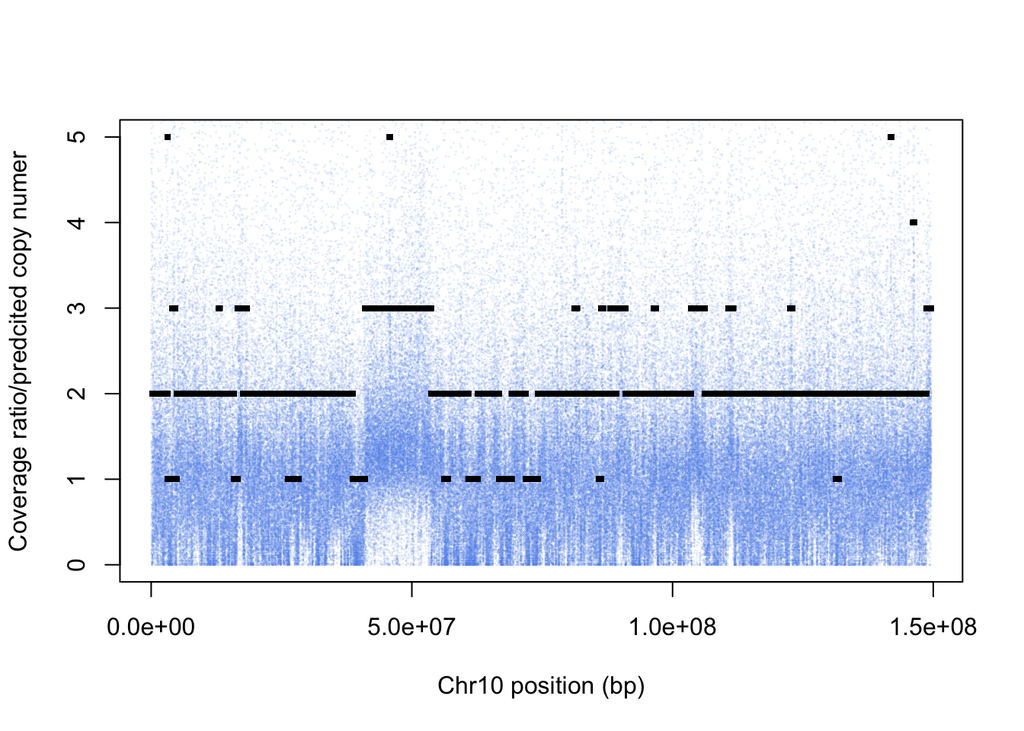